# Initalization

## Comparing data before and after covid

To research the impact of covid on income of Software developers, we decided to research periods before and after covid. But as our data is pooled cross sectional data (unlike time series data, in our data time periods between observations are inconsistent and objects of observation are different), so before comparing this two periods we need to show that the sampling method did not change over the time. We assume that smpling is random over all of the data, and to show that we show that data before covid is proportional(by that we mean that probortions of difrent values are aproximatly the same for every variable that do not depend on time) to data after

```python
before_covid_df = df[df.index < pd.to_datetime('2019-01-01')]
```

```python
after_covid_df = df[df.index > pd.to_datetime('2019-01-01')]
```

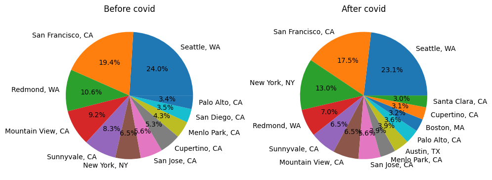

```python
category_counts = before_covid_df['location'].value_counts()

category_percentages = category_counts / category_counts.sum() * 100
threshold = 2
category_counts_df1 = category_percentages[category_percentages > threshold]

category_counts = after_covid_df['location'].value_counts()

category_percentages = category_counts / category_counts.sum() * 100
threshold = 2
category_counts_df2 = category_percentages[category_percentages > threshold]

fig, axes = plt.subplots(1, 2, figsize=(10, 5))

axes[0].pie(category_counts_df1, labels=category_counts_df1.index, autopct='%1.1f%%')
axes[0].set_title('Before covid')

axes[1].pie(category_counts_df2, labels=category_counts_df2.index, autopct='%1.1f%%')
axes[1].set_title('After covid')

plt.tight_layout()

plt.show()
```

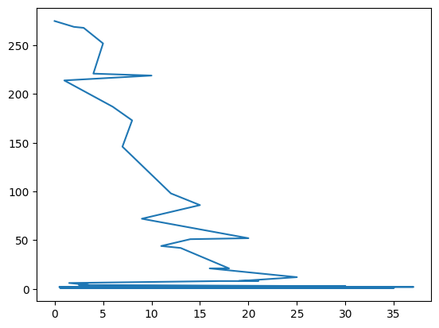

```python
category_counts = before_covid_df['yearsofexperience'].value_counts()
category_counts.plot()
```

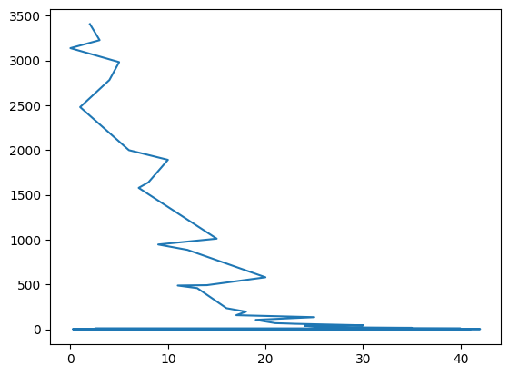

```python
category_counts = after_covid_df['yearsofexperience'].value_counts()
category_counts.plot()
```

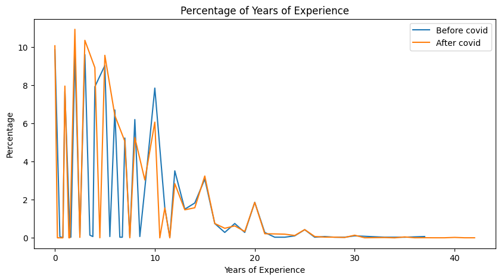

```python
value_counts_df1 = before_covid_df['yearsofexperience'].value_counts().sort_index()
total_count_df1 = value_counts_df1.sum()
percentages_df1 = value_counts_df1 / total_count_df1 * 100
value_counts_df2 = after_covid_df['yearsofexperience'].value_counts().sort_index()
total_count_df2 = value_counts_df2.sum()
percentages_df2 = value_counts_df2 / total_count_df2 * 100
fig, ax = plt.subplots(figsize=(10, 5))
ax.plot(percentages_df1.index, percentages_df1.values, label='Before covid')
ax.plot(percentages_df2.index, percentages_df2.values, label='After covid')
ax.set_xlabel('Years of Experience')
ax.set_ylabel('Percentage')
ax.set_title('Percentage of Years of Experience')
ax.legend()
plt.show()
```

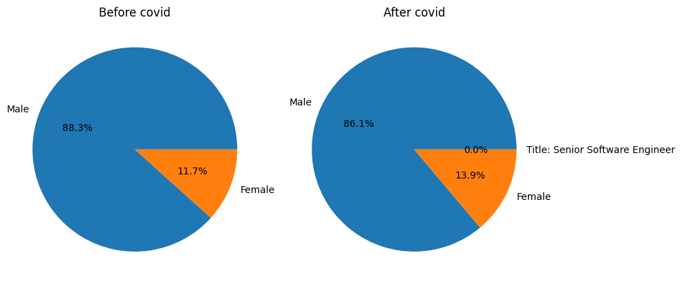

```python
category_counts_df1 = before_covid_df['gender'].value_counts()
category_counts_df2 = after_covid_df['gender'].value_counts()

fig, axes = plt.subplots(1, 2, figsize=(10, 5))

axes[0].pie(category_counts_df1, labels=category_counts_df1.index, autopct='%1.1f%%')
axes[0].set_title('Before covid')

axes[1].pie(category_counts_df2, labels=category_counts_df2.index, autopct='%1.1f%%')
axes[1].set_title('After covid')

plt.tight_layout()

plt.show()
```

```python
vars = ['totalyearlycompensation','yearsofexperience','yearsatcompany', 'Doctorate_Degree',
       'gender_Male','inflation']
corr_matrix = before_covid_df[vars].corr()
corr_matrix.style.background_gradient(cmap='coolwarm')
```

|  | totalyearlycompensation | yearsofexperience | yearsatcompany | Doctorate_Degree | gender_Male | inflation |
| --- | --- | --- | --- | --- | --- | --- |
| totalyearlycompensation | 1.000000 | 0.491497 | 0.223079 | 0.008643 | 0.011256 | -0.048322 |
| yearsofexperience | 0.491497 | 1.000000 | 0.532646 | -0.011244 | 0.001935 | -0.020923 |
| yearsatcompany | 0.223079 | 0.532646 | 1.000000 | -0.018681 | -0.025778 | -0.027226 |
| Doctorate_Degree | 0.008643 | -0.011244 | -0.018681 | 1.000000 | -0.020530 | -0.057623 |
| gender_Male | 0.011256 | 0.001935 | -0.025778 | -0.020530 | 1.000000 | 0.169450 |
| inflation | -0.048322 | -0.020923 | -0.027226 | -0.057623 | 0.169450 | 1.000000 |

```python
corr_matrix = after_covid_df[['totalyearlycompensation','days_from_start_of_recording','yearsofexperience','yearsatcompany', 'Bachelors_Degree', 'Doctorate_Degree',
'Highschool', 'Some_College', 'Race_Asian', 'Race_White', 'Race_Black', 'Race_Hispanic','gender_Male','inflation']].corr()
corr_matrix.style.background_gradient(cmap='coolwarm')
```

|  | totalyearlycompensation | days_from_start_of_recording | yearsofexperience | yearsatcompany | Bachelors_Degree | Doctorate_Degree | Highschool | Some_College | Race_Asian | Race_White | Race_Black | Race_Hispanic | gender_Male | inflation |
| --- | --- | --- | --- | --- | --- | --- | --- | --- | --- | --- | --- | --- | --- | --- |
| totalyearlycompensation | 1.000000 | -0.022529 | 0.429168 | 0.155971 | -0.095902 | 0.138734 | -0.004235 | -0.002124 | -0.025086 | -0.020782 | -0.040667 | -0.033345 | -0.012223 | -0.010956 |
| days_from_start_of_recording | -0.022529 | 1.000000 | -0.016479 | -0.017852 | 0.343588 | 0.022567 | 0.048915 | 0.052345 | 0.341060 | 0.254318 | 0.067812 | 0.089681 | -0.131774 | 0.698251 |
| yearsofexperience | 0.429168 | -0.016479 | 1.000000 | 0.543826 | -0.058914 | 0.015732 | 0.009261 | 0.044729 | -0.054162 | 0.080218 | -0.035324 | -0.015503 | 0.042747 | -0.003597 |
| yearsatcompany | 0.155971 | -0.017852 | 0.543826 | 1.000000 | -0.012753 | 0.012026 | -0.009400 | 0.008016 | -0.023087 | 0.062029 | -0.030147 | -0.016753 | 0.030866 | -0.000354 |
| Bachelors_Degree | -0.095902 | 0.343588 | -0.058914 | -0.012753 | 1.000000 | -0.081456 | -0.032502 | -0.038117 | 0.199937 | 0.420427 | 0.130549 | 0.168518 | 0.185567 | 0.219871 |
| Doctorate_Degree | 0.138734 | 0.022567 | 0.015732 | 0.012026 | -0.081456 | 1.000000 | -0.010803 | -0.012670 | 0.038929 | 0.028379 | -0.008959 | -0.001684 | 0.043594 | -0.015789 |
| Highschool | -0.004235 | 0.048915 | 0.009261 | -0.009400 | -0.032502 | -0.010803 | 1.000000 | -0.005055 | -0.012520 | 0.110813 | 0.002946 | 0.038428 | 0.045081 | 0.040121 |
| Some_College | -0.002124 | 0.052345 | 0.044729 | 0.008016 | -0.038117 | -0.012670 | -0.005055 | 1.000000 | -0.018549 | 0.131477 | 0.041666 | 0.039301 | 0.049958 | 0.029315 |
| Race_Asian | -0.025086 | 0.341060 | -0.054162 | -0.023087 | 0.199937 | 0.038929 | -0.012520 | -0.018549 | 1.000000 | -0.173320 | -0.048978 | -0.064843 | 0.199568 | 0.229077 |
| Race_White | -0.020782 | 0.254318 | 0.080218 | 0.062029 | 0.420427 | 0.028379 | 0.110813 | 0.131477 | -0.173320 | 1.000000 | -0.037110 | -0.049595 | 0.202894 | 0.172303 |
| Race_Black | -0.040667 | 0.067812 | -0.035324 | -0.030147 | 0.130549 | -0.008959 | 0.002946 | 0.041666 | -0.048978 | -0.037110 | 1.000000 | -0.014015 | 0.049497 | 0.033272 |
| Race_Hispanic | -0.033345 | 0.089681 | -0.015503 | -0.016753 | 0.168518 | -0.001684 | 0.038428 | 0.039301 | -0.064843 | -0.049595 | -0.014015 | 1.000000 | 0.080744 | 0.050121 |
| gender_Male | -0.012223 | -0.131774 | 0.042747 | 0.030866 | 0.185567 | 0.043594 | 0.045081 | 0.049958 | 0.199568 | 0.202894 | 0.049497 | 0.080744 | 1.000000 | -0.060325 |
| inflation | -0.010956 | 0.698251 | -0.003597 | -0.000354 | 0.219871 | -0.015789 | 0.040121 | 0.029315 | 0.229077 | 0.172303 | 0.033272 | 0.050121 | -0.060325 | 1.000000 |

## Regression Discontinuity Design

Here to show the impact of covid on the total yearly compensation, we used Regression Discontinuity Design. We implemented two models that are supposed to aproxiate the impact of covid on income of software ingeneers. First - build the regression model with dummie variable that incates weather observation is before or after covid, fit this regression, and than test its significance and observe its cooficient(the cooficient actually will be the inpact on the income if significant). See this method in the next section. The other model is more complex, for data before and after covid we construct the regression. And after that the gap between the two regressions at the point of beginig of covid will be the inpact of covid on income.

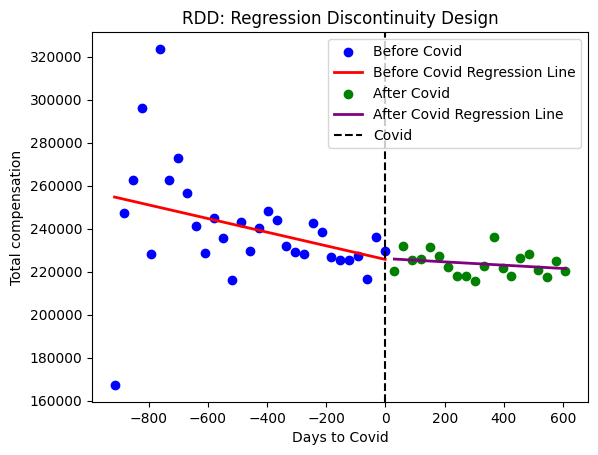

```python
def rrd_average(cutoff_date, coulmn_name):
  avarege_by_month['covid'] = np.where(avarege_by_month.index >= cutoff_date, 1, 0)
  avarege_by_month['distance'] = (avarege_by_month.index - cutoff_date).days
  df_before_cutoff = avarege_by_month[avarege_by_month['covid'] == 0]
  df_after_cutoff = avarege_by_month[avarege_by_month['covid'] == 1]
  X_before = df_before_cutoff['distance']
  X_before = sm.add_constant(X_before)
  y_before = df_before_cutoff[coulmn_name]
  model_before = sm.OLS(y_before, X_before)
  results_before = model_before.fit()

  X_after = df_after_cutoff['distance']
  X_after = sm.add_constant(X_after)
  y_after = df_after_cutoff[coulmn_name]
  model_after = sm.OLS(y_after, X_after)
  results_after = model_after.fit()

  plt.scatter(df_before_cutoff['distance'], df_before_cutoff[coulmn_name], color='blue', label='Before Covid')
  plt.plot(df_before_cutoff['distance'], results_before.predict(X_before), color='red', linewidth=2, label='Before Covid Regression Line')

  plt.scatter(df_after_cutoff['distance'], df_after_cutoff[coulmn_name], color='green', label='After Covid')
  plt.plot(df_after_cutoff['distance'], results_after.predict(X_after), color='purple', linewidth=2, label='After Covid Regression Line')

  plt.axvline(x=0, color='black', linestyle='--', label='Covid')
  plt.xlabel('Days to Covid')
  plt.ylabel('Total compensation')
  plt.title('RDD: Regression Discontinuity Design')
  plt.legend()
  plt.show()
cutoff_date = pd.to_datetime('2020-01-01')
rrd_average(cutoff_date, 'totalyearlycompensation')
```

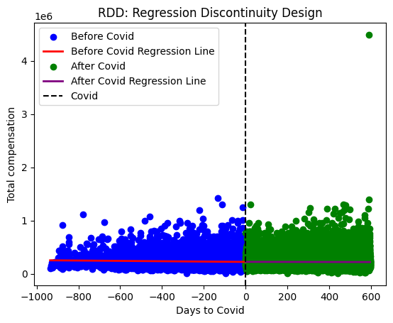

```python
def rrd(cutoff_date, coulmn_name):
  df['covid'] = np.where(df.index >= cutoff_date, 1, 0)
  df['distance'] = (df.index - cutoff_date).days
  df_before_cutoff = df[df['covid'] == 0]
  df_after_cutoff = df[df['covid'] == 1]
  X_before = df_before_cutoff['distance']
  X_before = sm.add_constant(X_before)
  y_before = df_before_cutoff[coulmn_name]
  model_before = sm.OLS(y_before, X_before)
  results_before = model_before.fit()

  X_after = df_after_cutoff['distance']
  X_after = sm.add_constant(X_after)
  y_after = df_after_cutoff[coulmn_name]
  model_after = sm.OLS(y_after, X_after)
  results_after = model_after.fit()

  plt.scatter(df_before_cutoff['distance'], df_before_cutoff[coulmn_name], color='blue', label='Before Covid')
  plt.plot(df_before_cutoff['distance'], results_before.predict(X_before), color='red', linewidth=2, label='Before Covid Regression Line')

  plt.scatter(df_after_cutoff['distance'], df_after_cutoff[coulmn_name], color='green', label='After Covid')
  plt.plot(df_after_cutoff['distance'], results_after.predict(X_after), color='purple', linewidth=2, label='After Covid Regression Line')

  plt.axvline(x=0, color='black', linestyle='--', label='Covid')
  plt.xlabel('Days to Covid')
  plt.ylabel('Total compensation')
  plt.title('RDD: Regression Discontinuity Design')
  plt.legend()
  plt.show()
cutoff_date = pd.to_datetime('2020-01-01')
rrd(cutoff_date, 'totalyearlycompensation')
```

```python
df['totalyearlycompensationadjusted'] = df['totalyearlycompensation']/df['inflation_comulative']
```

```python
avarege_by_month = df.resample('1M').mean()
```

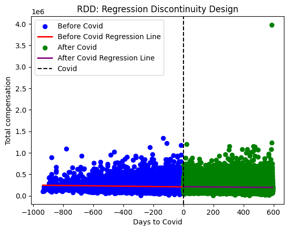

```python
rrd(cutoff_date,'totalyearlycompensationadjusted')
```

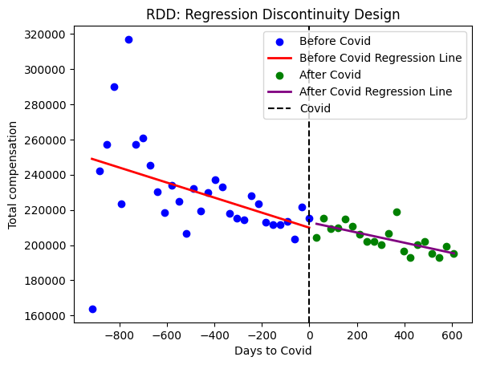

```python
rrd_average(cutoff_date, 'totalyearlycompensationadjusted')
```

Surprisingly, this model did not show the big impact of covid on total yearly compenstaion(two models show almost no gap between two regressions). First model show that after covid income starts to decrease slower, but the natural suggestion that it could be because of the rapidly growing inflation after start of covid. Next model takes inflation to the considiration. Here two regresion lines are almost onle line. It means that covid did not infuence total yearly compenstation according to data in our dataset.

## Regressions for total yearly compensation

```python
y = df['totalyearlycompensation']
x = df[['yearsofexperience',
        'yearsatcompany', 'Masters_Degree', 'Bachelors_Degree', 'Doctorate_Degree',
       'Highschool', 'Some_College', 'Race_Asian', 'Race_White',
       'Race_Two_Or_More', 'Race_Black', 'Race_Hispanic',
       'days_from_start_of_recording', 'gender_Male', 'covid']]
x = sm.add_constant(x)
lin_model_all_included = sm.OLS(y, x).fit()
print(lin_model_all_included.summary())
```

```
                               OLS Regression Results
===================================================================================
Dep. Variable:     totalyearlycompensation   R-squared:                       0.219
Model:                                 OLS   Adj. R-squared:                  0.218
Method:                      Least Squares   F-statistic:                     634.7
Date:                     Tue, 23 May 2023   Prob (F-statistic):               0.00
Time:                             19:42:21   Log-Likelihood:            -4.4178e+05
No. Observations:                    34014   AIC:                         8.836e+05
Df Residuals:                        33998   BIC:                         8.837e+05
Df Model:                               15
Covariance Type:                 nonrobust
================================================================================================
                                   coef    std err          t      P>|t|      [0.025      0.975]
------------------------------------------------------------------------------------------------
const                         1.772e+05   2846.360     62.242      0.000    1.72e+05    1.83e+05
yearsofexperience             1.089e+04    127.703     85.266      0.000    1.06e+04    1.11e+04
yearsatcompany               -4232.1350    231.794    -18.258      0.000   -4686.459   -3777.811
Masters_Degree                3608.3295   1844.316      1.956      0.050      -6.592    7223.251
Bachelors_Degree             -5971.8801   2348.468     -2.543      0.011   -1.06e+04   -1368.803
Doctorate_Degree              9.963e+04   3873.953     25.719      0.000     9.2e+04    1.07e+05
Highschool                   -2589.3262   9422.787     -0.275      0.783   -2.11e+04    1.59e+04
Some_College                 -1.982e+04   8147.164     -2.433      0.015   -3.58e+04   -3852.582
Race_Asian                   -3541.7222   2156.507     -1.642      0.101   -7768.548     685.104
Race_White                   -1.689e+04   2608.482     -6.474      0.000    -2.2e+04   -1.18e+04
Race_Two_Or_More             -1393.8249   5887.233     -0.237      0.813   -1.29e+04    1.01e+04
Race_Black                   -2.736e+04   6190.860     -4.419      0.000   -3.95e+04   -1.52e+04
Race_Hispanic                -2.152e+04   4815.754     -4.469      0.000    -3.1e+04   -1.21e+04
days_from_start_of_recording     0.4764      3.489      0.137      0.891      -6.362       7.315
gender_Male                  -5346.0446   1312.847     -4.072      0.000   -7919.269   -2772.820
covid                        -5396.2882   2381.330     -2.266      0.023   -1.01e+04    -728.802
==============================================================================
Omnibus:                    30750.537   Durbin-Watson:                   1.922
Prob(Omnibus):                  0.000   Jarque-Bera (JB):          9415013.873
Skew:                           3.585   Prob(JB):                         0.00
Kurtosis:                      84.190   Cond. No.                     1.91e+04
==============================================================================

Notes:
[1] Standard Errors assume that the covariance matrix of the errors is correctly specified.
[2] The condition number is large, 1.91e+04. This might indicate that there are
strong multicollinearity or other numerical problems.
```

```python
y = df['totalyearlycompensation']
x = df[['yearsofexperience',
        'yearsatcompany', 'Bachelors_Degree', 'Doctorate_Degree',
        'Some_College', 'Race_Asian',
       'gender_Male', 'covid']]
x = sm.add_constant(x)
lin_model_some_included = sm.OLS(y, x).fit()
print(lin_model_some_included.summary())
```

```
                               OLS Regression Results
===================================================================================
Dep. Variable:     totalyearlycompensation   R-squared:                       0.217
Model:                                 OLS   Adj. R-squared:                  0.217
Method:                      Least Squares   F-statistic:                     1180.
Date:                     Tue, 23 May 2023   Prob (F-statistic):               0.00
Time:                             19:45:04   Log-Likelihood:            -4.4181e+05
No. Observations:                    34014   AIC:                         8.836e+05
Df Residuals:                        34005   BIC:                         8.837e+05
Df Model:                                8
Covariance Type:                 nonrobust
=====================================================================================
                        coef    std err          t      P>|t|      [0.025      0.975]
-------------------------------------------------------------------------------------
const              1.793e+05   1438.690    124.616      0.000    1.76e+05    1.82e+05
yearsofexperience  1.086e+04    127.539     85.125      0.000    1.06e+04    1.11e+04
yearsatcompany    -4238.5431    231.832    -18.283      0.000   -4692.941   -3784.145
Bachelors_Degree  -1.553e+04   1631.182     -9.519      0.000   -1.87e+04   -1.23e+04
Doctorate_Degree     9.6e+04   3768.681     25.472      0.000    8.86e+04    1.03e+05
Some_College      -3.293e+04   7879.168     -4.180      0.000   -4.84e+04   -1.75e+04
Race_Asian         4354.0191   1653.608      2.633      0.008    1112.892    7595.146
gender_Male       -7437.9257   1232.646     -6.034      0.000   -9853.954   -5021.898
covid             -7189.2476   1383.183     -5.198      0.000   -9900.333   -4478.162
==============================================================================
Omnibus:                    30714.843   Durbin-Watson:                   1.923
Prob(Omnibus):                  0.000   Jarque-Bera (JB):          9364025.749
Skew:                           3.578   Prob(JB):                         0.00
Kurtosis:                      83.969   Cond. No.                         120.
==============================================================================

Notes:
[1] Standard Errors assume that the covariance matrix of the errors is correctly specified.
```

```python
df['log_experience'] = np.log(df['yearsofexperience'])
df['log_at_company'] = np.log(df['yearsatcompany'])
```

```python
y = df['totalyearlycompensation']
x = df[['log_experience', 'yearsatcompany', 'Bachelors_Degree', 'Doctorate_Degree',
       'Race_Black', 'Race_Hispanic',
       'covid']]

x = x.loc[:, x.var() > 0.0001]
x = (x - x.mean()) / x.std()
x = sm.add_constant(x)
lin_model_log_experience = sm.OLS(y, x).fit(max_iter=1000)

print(lin_model_log_experience.summary())
```

```
                               OLS Regression Results
===================================================================================
Dep. Variable:     totalyearlycompensation   R-squared:                       0.051
Model:                                 OLS   Adj. R-squared:                  0.051
Method:                      Least Squares   F-statistic:                     305.5
Date:                     Tue, 23 May 2023   Prob (F-statistic):               0.00
Time:                             19:45:45   Log-Likelihood:            -4.4508e+05
No. Observations:                    34014   AIC:                         8.902e+05
Df Residuals:                        34007   BIC:                         8.902e+05
Df Model:                                6
Covariance Type:                 nonrobust
====================================================================================
                       coef    std err          t      P>|t|      [0.025      0.975]
------------------------------------------------------------------------------------
const              2.26e+05    632.191    357.441      0.000    2.25e+05    2.27e+05
yearsatcompany    1.898e+04    632.706     29.996      0.000    1.77e+04    2.02e+04
Bachelors_Degree -8916.7948    681.331    -13.087      0.000   -1.03e+04   -7581.364
Doctorate_Degree  1.489e+04    636.263     23.395      0.000    1.36e+04    1.61e+04
Race_Black       -2857.7565    638.781     -4.474      0.000   -4109.788   -1605.725
Race_Hispanic    -2045.1137    642.753     -3.182      0.001   -3304.931    -785.297
covid            -1522.0520    668.026     -2.278      0.023   -2831.405    -212.699
==============================================================================
Omnibus:                    28682.784   Durbin-Watson:                   1.921
Prob(Omnibus):                  0.000   Jarque-Bera (JB):          4749451.914
Skew:                           3.352   Prob(JB):                         0.00
Kurtosis:                      60.500   Cond. No.                         1.49
==============================================================================

Notes:
[1] Standard Errors assume that the covariance matrix of the errors is correctly specified.
```

```python
y = df['totalyearlycompensation']
x = df[['log_experience',
        'log_experience', 'Masters_Degree', 'Bachelors_Degree', 'Doctorate_Degree',
       'Race_Asian',
       'Race_Black', 'Race_Hispanic',
       'covid']]
x = sm.add_constant(x)
x = x.loc[:, x.var() > 0.0001]
x = (x - x.mean()) / x.std()
x = sm.add_constant(x)
lin_model_log_experience_and_company = sm.OLS(y, x).fit(max_iter=1000)

print(lin_model_log_experience_and_company.summary())
```

```
                               OLS Regression Results
===================================================================================
Dep. Variable:     totalyearlycompensation   R-squared:                       0.027
Model:                                 OLS   Adj. R-squared:                  0.026
Method:                      Least Squares   F-statistic:                     132.7
Date:                     Tue, 23 May 2023   Prob (F-statistic):          1.11e-193
Time:                             19:46:04   Log-Likelihood:            -4.4552e+05
No. Observations:                    34014   AIC:                         8.911e+05
Df Residuals:                        34006   BIC:                         8.911e+05
Df Model:                                7
Covariance Type:                 nonrobust
====================================================================================
                       coef    std err          t      P>|t|      [0.025      0.975]
------------------------------------------------------------------------------------
const              2.26e+05    640.327    352.899      0.000    2.25e+05    2.27e+05
Masters_Degree    2340.0237    786.525      2.975      0.003     798.408    3881.639
Bachelors_Degree -7541.6156    784.260     -9.616      0.000   -9078.792   -6004.439
Doctorate_Degree  1.549e+04    653.224     23.710      0.000    1.42e+04    1.68e+04
Race_Asian       -3155.9621    754.241     -4.184      0.000   -4634.300   -1677.624
Race_Black       -3711.3309    650.856     -5.702      0.000   -4987.030   -2435.632
Race_Hispanic    -2737.1308    657.466     -4.163      0.000   -4025.787   -1448.474
covid            -1898.0370    730.503     -2.598      0.009   -3329.848    -466.226
==============================================================================
Omnibus:                    28965.955   Durbin-Watson:                   1.924
Prob(Omnibus):                  0.000   Jarque-Bera (JB):          4741982.519
Skew:                           3.414   Prob(JB):                         0.00
Kurtosis:                      60.439   Cond. No.                         2.21
==============================================================================

Notes:
[1] Standard Errors assume that the covariance matrix of the errors is correctly specified.
```

```python
y = df['gender_Male']
x = df[['yearsofexperience', 'totalyearlycompensation',
       'Masters_Degree', 'Bachelors_Degree', 'Doctorate_Degree',
       'Highschool', 'Some_College', 'Race_Asian', 'Race_White',
       'Race_Two_Or_More', 'Race_Black', 'Race_Hispanic'
       ]]
x = sm.add_constant(x)
logit_all_some_included = sm.Logit(y, x).fit()
print(logit_all_some_included.summary())
```

```
Optimization terminated successfully.
         Current function value: 18.193864
         Iterations 7
                           Logit Regression Results
==============================================================================
Dep. Variable:            gender_Male   No. Observations:                34014
Model:                          Logit   Df Residuals:                    34001
Method:                           MLE   Df Model:                           12
Date:                Tue, 23 May 2023   Pseudo R-squ.:                     inf
Time:                        19:42:22   Log-Likelihood:            -6.1885e+05
converged:                       True   LL-Null:                        0.0000
Covariance Type:            nonrobust   LLR p-value:                     1.000
===========================================================================================
                              coef    std err          z      P>|z|      [0.025      0.975]
-------------------------------------------------------------------------------------------
const                      -0.2572      0.028     -9.308      0.000      -0.311      -0.203
yearsofexperience           0.0193      0.003      7.629      0.000       0.014       0.024
totalyearlycompensation -3.718e-07   1.13e-07     -3.296      0.001   -5.93e-07   -1.51e-07
Masters_Degree              0.7607      0.035     21.459      0.000       0.691       0.830
Bachelors_Degree            0.3596      0.050      7.223      0.000       0.262       0.457
Doctorate_Degree            0.7087      0.086      8.265      0.000       0.541       0.877
Highschool                  1.6118      0.396      4.066      0.000       0.835       2.389
Some_College                1.1606      0.296      3.926      0.000       0.581       1.740
Race_Asian                  1.1460      0.046     25.008      0.000       1.056       1.236
Race_White                  1.7869      0.065     27.370      0.000       1.659       1.915
Race_Two_Or_More            1.4796      0.151      9.780      0.000       1.183       1.776
Race_Black                  1.5196      0.161      9.453      0.000       1.205       1.835
Race_Hispanic               1.9880      0.145     13.686      0.000       1.703       2.273
===========================================================================================
```

```python
stargazer = Stargazer([lin_model_all_included,lin_model_some_included, lin_model_log_experience,lin_model_log_experience_and_company])
display(HTML(stargazer.render_html()))
```

[output not shown]

But note that averege income according to our dataset is decreasing even before covid. This means that recordings after covid that are obviously later in time have smaller total income. And covid variable could only be with negative cooef just because of that.

## Overview of trends

```python
inflation
```

| year | date | Inflation Rate (%) | Annual Change |  | inflation | inflation_comulative |
| --- | --- | --- | --- | --- | --- | --- |
| 2017 | 2017-12-31 | 2.1301 | 0.87 | NaN | 1.021301 | 1.021301 |
| 2018 | 2018-12-31 | 2.4426 | 0.31 | NaN | 1.024426 | 1.046247 |
| 2019 | 2019-12-31 | 1.8122 | -0.63 | NaN | 1.018122 | 1.065207 |
| 2020 | 2020-12-31 | 1.2336 | -0.58 | NaN | 1.012336 | 1.078348 |
| 2021 | 2021-12-31 | 4.6979 | 3.46 | NaN | 1.046979 | 1.129007 |

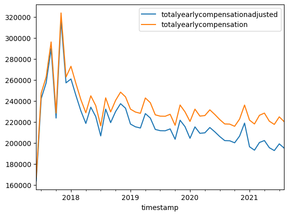

```python
avarege_by_month['totalyearlycompensationadjusted'].plot()
avarege_by_month['totalyearlycompensation'].plot()
plt.legend()
```

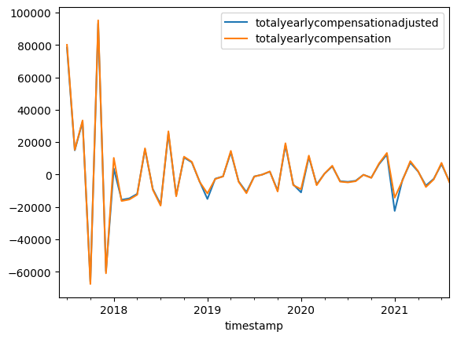

```python
avarege_by_month['totalyearlycompensationadjusted'].diff().plot()
avarege_by_month['totalyearlycompensation'].diff().plot()
plt.legend()
```

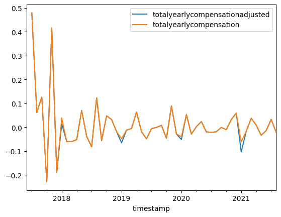

```python
avarege_by_month['totalyearlycompensationadjusted'].pct_change().plot()
avarege_by_month['totalyearlycompensation'].pct_change().plot()
plt.legend()
```

After some tries of deterending we decided not to countinue, because it is hard to use time series methods on our data. And to find some trends over the time we might need to use another data likely penel or time series.